# Week 8

## Skills

This week we will target the following skills:

1. Working with data in R
2. Mastering `if` and `else` statements
3. Commenting code
4. Combine the skills learnt so far, and exercise some communication skills

## Applied skills, exercises, resources.

All the references for this week link to “Hands-On Programming with R”, by Garrett Grolemund. You can get a physical copy of the book if you wish, but the standard and better way to access it is the free-to-use website: [https://RStudio-education.github.io/hopr/index.html](https://rstudio-education.github.io/hopr/index.html). The required readings for this weeks are:

- Section 5.1 to 5.11
- Section 6.1, 6.4
- Section 7.0.1, 7.0.2, 7.0.3
- Section 9.2, 9.3, 9.5 (9.1 for your interest)

The following is a mixture of exercises and exploratory activities that you have to go through. The right approach is to first read the sources (i.e., the sections listed above), and then to go through each block in this document. Please do not advance unless you are confident you are mastering the content.

### 1. Working with data in R [Sections 5.1 to 5.11, Appendix D, 6.1, 6.4, 7.0.1, 7.0.3]

*Learning outcomes:*

- *Understanding, creating and working with basic R objects (mostly data structures) [Section 5.1 to 5.8]*
- *Loading and saving data [Section 5.9 to 5.11 and Appendix D]*
- *Selecting and modifying values [Section 6.1, 6.4, 7.0.1, 7.0.2]*
- *Dealing with missing values [Section 7.0.3]*

#### Instructions:

It is important to know and understand the differences among the basic data structors in R, and their types. As a quick summary, we will consider the following data structures:

- atomic vectors
- matrices
- arrays
- lists
- data frames

and the following types:

- doubles
- integers
- characters
- logicals
- factors
- *complex and raw (we’ll skip these as they are not commonly used in basic Statistics)*

#### Exploratory activity

Type the following commands, followed by enter, and observe the output. In the following there are different level of complexity. Can you explain what is happening with each command? As usual, use the `help()` command to learn about new commands.

##### Atomic vectors, doubles

```r
x <- c(1, 2, 3, 4, 5, 6)
x
```

```
## [1] 1 2 3 4 5 6
```

```r
typeof(x)
```

```
## [1] "double"
```

```r
class(x)
```

```
## [1] "numeric"
```

```r
str(x)
```

```
##  num [1:6] 1 2 3 4 5 6
```

```r
x <- 1:6
x
```

```
## [1] 1 2 3 4 5 6
```

```r
typeof(x)
```

```
## [1] "integer"
```

```r
class(x)
```

```
## [1] "integer"
```

```r
str(x)
```

```
##  int [1:6] 1 2 3 4 5 6
```

```r
x <- seq(1, 6, len=6)
x
```

```
## [1] 1 2 3 4 5 6
```

```r
typeof(x)
```

```
## [1] "double"
```

```r
class(x)
```

```
## [1] "numeric"
```

```r
str(x)
```

```
##  num [1:6] 1 2 3 4 5 6
```

##### Atomic vectors, integers

```r
x <- c(1L, 2L, 3L, 4L, 5L, 6L)
x
```

```
## [1] 1 2 3 4 5 6
```

```r
typeof(x)
```

```
## [1] "integer"
```

```r
class(x)
```

```
## [1] "integer"
```

```r
str(x)
```

```
##  int [1:6] 1 2 3 4 5 6
```

```r
x <- c(1, 2, 3, 4, 5L, 6L)
x
```

```
## [1] 1 2 3 4 5 6
```

```r
typeof(x)
```

```
## [1] "double"
```

```r
class(x)
```

```
## [1] "numeric"
```

```r
str(x)
```

```
##  num [1:6] 1 2 3 4 5 6
```

```r
x <- as.integer(x)
x
```

```
## [1] 1 2 3 4 5 6
```

```r
typeof(x)
```

```
## [1] "integer"
```

```r
class(x)
```

```
## [1] "integer"
```

```r
str(x)
```

```
##  int [1:6] 1 2 3 4 5 6
```

##### Atomic vectors, characters

```r
x <- "This"
x
```

```
## [1] "This"
```

```r
typeof(x)
```

```
## [1] "character"
```

```r
class(x)
```

```
## [1] "character"
```

```r
str(x)
```

```
##  chr "This"
```

```r
x <- c("This", "unit", "is", "great.", "Do", "you", "agree?")
x
```

```
## [1] "This"   "unit"   "is"     "great." "Do"     "you"    "agree?"
```

```r
typeof(x)
```

```
## [1] "character"
```

```r
class(x)
```

```
## [1] "character"
```

```r
str(x)
```

```
##  chr [1:7] "This" "unit" "is" "great." "Do" "you" "agree?"
```

```r
x = paste("This", "unit", "is", "great.", "Do", "you", "agree?", sep="::")
x
```

```
## [1] "This::unit::is::great.::Do::you::agree?"
```

```r
typeof(x)
```

```
## [1] "character"
```

```r
class(x)
```

```
## [1] "character"
```

```r
str(x)
```

```
##  chr "This::unit::is::great.::Do::you::agree?"
```

```r
x = paste("This", "unit", "is", "great.", "Do", "you", "agree?", sep=" ")
x
```

```
## [1] "This unit is great. Do you agree?"
```

```r
typeof(x)
```

```
## [1] "character"
```

```r
class(x)
```

```
## [1] "character"
```

```r
str(x)
```

```
##  chr "This unit is great. Do you agree?"
```

```r
cat("This", "unit", "is", "great.", "Do", "you", "agree?", sep="\t")
```

```
## This unit    is  great.  Do  you agree?
```

```r
cat("This", "unit", "is", "great.", "Do", "you", "agree?", sep="\n")
```

```
## This
## unit
## is
## great.
## Do
## you
## agree?
```

```r
cat("This", "unit", "is", "great.","\n", "Do", "you", "agree?")
```

```
## This unit is great.
##  Do you agree?
```

```r
cat("This ", "unit ", "is ", "great.","\n", "Do ", "you ", "agree? ", sep="")
```

```
## This unit is great.
## Do you agree?
```

##### Atomic vectors, logicals

```r
1>0
```

```
## [1] TRUE
```

```r
1<0
```

```
## [1] FALSE
```

```r
1=1
```

```
## Error in 1 = 1: invalid (do_set) left-hand side to assignment
```

```r
1==1
```

```
## [1] TRUE
```

```r
x <- c(TRUE, TRUE, FALSE)
x
```

```
## [1]  TRUE  TRUE FALSE
```

```r
typeof(x)
```

```
## [1] "logical"
```

```r
class(x)
```

```
## [1] "logical"
```

```r
str(x)
```

```
##  logi [1:3] TRUE TRUE FALSE
```

```r
x <- c(T, T, F)
x
```

```
## [1]  TRUE  TRUE FALSE
```

```r
typeof(x)
```

```
## [1] "logical"
```

```r
class(x)
```

```
## [1] "logical"
```

```r
str(x)
```

```
##  logi [1:3] TRUE TRUE FALSE
```

```r
x= 1>0
x
```

```
## [1] TRUE
```

```r
typeof(x)
```

```
## [1] "logical"
```

```r
class(x)
```

```
## [1] "logical"
```

```r
str(x)
```

```
##  logi TRUE
```

```r
x <- c(1>0, 5>0, 5>10)
x
```

```
## [1]  TRUE  TRUE FALSE
```

```r
typeof(x)
```

```
## [1] "logical"
```

```r
class(x)
```

```
## [1] "logical"
```

```r
str(x)
```

```
##  logi [1:3] TRUE TRUE FALSE
```

##### Atomic vectors, factors

```r
x <- c("spring", "spring", "winter", "spring", "winter", "spring", "spring")
x
```

```
## [1] "spring" "spring" "winter" "spring" "winter" "spring" "spring"
```

```r
typeof(x)
```

```
## [1] "character"
```

```r
class(x)
```

```
## [1] "character"
```

```r
str(x)
```

```
##  chr [1:7] "spring" "spring" "winter" "spring" "winter" "spring" "spring"
```

```r
attributes(x)
```

[output not shown]

```r
x <- factor(c("spring", "spring", "winter", "spring", "winter", "spring", "spring"))
x
```

```
## [1] spring spring winter spring winter spring spring
## Levels: spring winter
```

```r
typeof(x)
```

```
## [1] "integer"
```

```r
class(x)
```

```
## [1] "factor"
```

```r
str(x)
```

```
##  Factor w/ 2 levels "spring","winter": 1 1 2 1 2 1 1
```

```r
attributes(x)
```

```
## $levels
## [1] "spring" "winter"
##
## $class
## [1] "factor"
```

```r
table(x)
```

```
## x
## spring winter
##      5      2
```

```r
as.character(x)
```

```
## [1] "spring" "spring" "winter" "spring" "winter" "spring" "spring"
```

##### Attributes

```r
x <- 1:6
attributes(x)
```

[output not shown]

```r
names(x)
```

[output not shown]

```r
names(x) <- c("Jan", "Feb", "Mar", "Apr", "May", "Jun")
names(x)
```

```
## [1] "Jan" "Feb" "Mar" "Apr" "May" "Jun"
```

```r
attributes(x)
```

```
## $names
## [1] "Jan" "Feb" "Mar" "Apr" "May" "Jun"
```

```r
str(x)
```

```
##  Named int [1:6] 1 2 3 4 5 6
##  - attr(*, "names")= chr [1:6] "Jan" "Feb" "Mar" "Apr" ...
```

```r
class(x)
```

```
## [1] "integer"
```

```r
x
```

```
## Jan Feb Mar Apr May Jun
##   1   2   3   4   5   6
```

```r
x <- 1:6
dim(x) <- c(2, 3)
attributes(x)
```

```
## $dim
## [1] 2 3
```

```r
str(x)
```

```
##  int [1:2, 1:3] 1 2 3 4 5 6
```

```r
class(x)
```

```
## [1] "matrix"
```

```r
x
```

```
##      [,1] [,2] [,3]
## [1,]    1    3    5
## [2,]    2    4    6
```

##### Matrices

```r
m <- matrix(1:6, nrow = 2)
str(m)
```

```
##  int [1:2, 1:3] 1 2 3 4 5 6
```

```r
class(m)
```

```
## [1] "matrix"
```

```r
m
```

```
##      [,1] [,2] [,3]
## [1,]    1    3    5
## [2,]    2    4    6
```

```r
m <- matrix(1:6, nrow = 2, byrow = TRUE)
str(m)
```

```
##  int [1:2, 1:3] 1 4 2 5 3 6
```

```r
class(m)
```

```
## [1] "matrix"
```

```r
m
```

```
##      [,1] [,2] [,3]
## [1,]    1    2    3
## [2,]    4    5    6
```

##### Arrays

```r
x <- array(c(1:5, 11:15), dim = c(5, 5))
str(x)
```

```
##  int [1:5, 1:5] 1 2 3 4 5 11 12 13 14 15 ...
```

```r
class(x)
```

```
## [1] "matrix"
```

```r
x
```

```
##      [,1] [,2] [,3] [,4] [,5]
## [1,]    1   11    1   11    1
## [2,]    2   12    2   12    2
## [3,]    3   13    3   13    3
## [4,]    4   14    4   14    4
## [5,]    5   15    5   15    5
```

```r
## R add to recycle values: we gave in input 10 values, but needed 25 (5*5)

x <- array(c(1:15, 21:30), dim = c(5, 5))
str(x)
```

```
##  int [1:5, 1:5] 1 2 3 4 5 6 7 8 9 10 ...
```

```r
class(x)
```

```
## [1] "matrix"
```

```r
x
```

```
##      [,1] [,2] [,3] [,4] [,5]
## [1,]    1    6   11   21   26
## [2,]    2    7   12   22   27
## [3,]    3    8   13   23   28
## [4,]    4    9   14   24   29
## [5,]    5   10   15   25   30
```

```r
x <- array(c(1:15, 21:30, 101:125), dim = c(5, 5, 2))
str(x)
```

```
##  int [1:5, 1:5, 1:2] 1 2 3 4 5 6 7 8 9 10 ...
```

```r
class(x)
```

```
## [1] "array"
```

```r
x
```

```
## , , 1
##
##      [,1] [,2] [,3] [,4] [,5]
## [1,]    1    6   11   21   26
## [2,]    2    7   12   22   27
## [3,]    3    8   13   23   28
## [4,]    4    9   14   24   29
## [5,]    5   10   15   25   30
##
## , , 2
##
##      [,1] [,2] [,3] [,4] [,5]
## [1,]  101  106  111  116  121
## [2,]  102  107  112  117  122
## [3,]  103  108  113  118  123
## [4,]  104  109  114  119  124
## [5,]  105  110  115  120  125
```

```r
x <- array(c(1:25, 101:125), dim = c(5, 5, 2))
str(x)
```

```
##  int [1:5, 1:5, 1:2] 1 2 3 4 5 6 7 8 9 10 ...
```

```r
class(x)
```

```
## [1] "array"
```

```r
x
```

```
## , , 1
##
##      [,1] [,2] [,3] [,4] [,5]
## [1,]    1    6   11   16   21
## [2,]    2    7   12   17   22
## [3,]    3    8   13   18   23
## [4,]    4    9   14   19   24
## [5,]    5   10   15   20   25
##
## , , 2
##
##      [,1] [,2] [,3] [,4] [,5]
## [1,]  101  106  111  116  121
## [2,]  102  107  112  117  122
## [3,]  103  108  113  118  123
## [4,]  104  109  114  119  124
## [5,]  105  110  115  120  125
```

##### Lists

```r
x <- list(1:5, 11:15, c("a", "b", "c"))
str(x)
```

```
## List of 3
##  $ : int [1:5] 1 2 3 4 5
##  $ : int [1:5] 11 12 13 14 15
##  $ : chr [1:3] "a" "b" "c"
```

```r
class(x)
```

```
## [1] "list"
```

```r
x
```

```
## [[1]]
## [1] 1 2 3 4 5
##
## [[2]]
## [1] 11 12 13 14 15
##
## [[3]]
## [1] "a" "b" "c"
```

```r
x <- list(x1=1:5, x2=11:15, x3=c("a", "b", "c"))
str(x)
```

```
## List of 3
##  $ x1: int [1:5] 1 2 3 4 5
##  $ x2: int [1:5] 11 12 13 14 15
##  $ x3: chr [1:3] "a" "b" "c"
```

```r
class(x)
```

```
## [1] "list"
```

```r
x
```

```
## $x1
## [1] 1 2 3 4 5
##
## $x2
## [1] 11 12 13 14 15
##
## $x3
## [1] "a" "b" "c"
```

```r
x <- list(x1=1:5, x2=11:15, x3=list(y1="a", y2="b", y3="c"))
str(x)
```

```
## List of 3
##  $ x1: int [1:5] 1 2 3 4 5
##  $ x2: int [1:5] 11 12 13 14 15
##  $ x3:List of 3
##   ..$ y1: chr "a"
##   ..$ y2: chr "b"
##   ..$ y3: chr "c"
```

```r
class(x)
```

```
## [1] "list"
```

```r
x
```

```
## $x1
## [1] 1 2 3 4 5
##
## $x2
## [1] 11 12 13 14 15
##
## $x3
## $x3$y1
## [1] "a"
##
## $x3$y2
## [1] "b"
##
## $x3$y3
## [1] "c"
```

##### Data frames

```r
x <- data.frame(season = c("winter", "winter", "spring", "spring"),
  month = c("Jan", "Feb", "Apr", "Apr"), station = c("Sydney" , "New Castle", "Sydney", "Melbourne"), temperature = c(14, 17, 26, 25))
str(x)
```

```
## 'data.frame':    4 obs. of  4 variables:
##  $ season     : Factor w/ 2 levels "spring","winter": 2 2 1 1
##  $ month      : Factor w/ 3 levels "Apr","Feb","Jan": 3 2 1 1
##  $ station    : Factor w/ 3 levels "Melbourne","New Castle",..: 3 2 3 1
##  $ temperature: num  14 17 26 25
```

```r
typeof(x)
```

```
## [1] "list"
```

```r
class(x)
```

```
## [1] "data.frame"
```

```r
x
```

```
##   season month    station temperature
## 1 winter   Jan     Sydney          14
## 2 winter   Feb New Castle          17
## 3 spring   Apr     Sydney          26
## 4 spring   Apr  Melbourne          25
```

##### Loading and saving data

Download the `test.csv` file from iLearn and copy it in your working directory. We are going to load the file using the command `read.csv()`. Explore the options of this command with `help('read.csv')`. Based on Appendix D, can you reproduce the behaviour of `read.csv()` using `read.table()`?

```r
x <- read.csv(file = "test.csv")
str(x)
```

```
## 'data.frame':    300 obs. of  3 variables:
##  $ season     : Factor w/ 4 levels "autumn","spring",..: 3 3 2 1 2 3 3 1 2 2 ...
##  $ station    : Factor w/ 4 levels "Adelaide","Melbourne",..: 2 2 3 3 1 3 2 4 4 2 ...
##  $ temperature: int  17 22 17 28 26 24 16 17 23 28 ...
```

```r
typeof(x)
```

```
## [1] "list"
```

```r
class(x)
```

```
## [1] "data.frame"
```

```r
x
```

```
##     season    station temperature
## 1   summer  Melbourne          17
## 2   summer  Melbourne          22
## 3   spring New Castle          17
## 4   autumn New Castle          28
## 5   spring   Adelaide          26
## 6   summer New Castle          24
## 7   summer  Melbourne          16
## 8   autumn     Sydney          17
## 9   spring     Sydney          23
## 10  spring  Melbourne          28
## 11  summer   Adelaide          26
## 12  winter     Sydney          27
## 13  summer  Melbourne          25
## 14  summer New Castle          16
```

[output cut: 286 more lines]

We can now create a data frame and save it to the file “my_data_file.csv” using the command `write.csv()`. Explore the options of this command with `help('write.csv')`. Check with Excel and/or a text editor if the file has been saved correctly.

```r
x <- data.frame(season = c("winter", "winter", "spring", "spring"),
  month = c("Jan", "Feb", "Apr", "Apr"), station = c("Sydney" , "New Castle", "Sydney", "Melbourne"), temperature = c(14, 17, 26, 25))
str(x)
```

```
## 'data.frame':    4 obs. of  4 variables:
##  $ season     : Factor w/ 2 levels "spring","winter": 2 2 1 1
##  $ month      : Factor w/ 3 levels "Apr","Feb","Jan": 3 2 1 1
##  $ station    : Factor w/ 3 levels "Melbourne","New Castle",..: 3 2 3 1
##  $ temperature: num  14 17 26 25
```

```r
typeof(x)
```

```
## [1] "list"
```

```r
class(x)
```

```
## [1] "data.frame"
```

```r
x
```

```
##   season month    station temperature
## 1 winter   Jan     Sydney          14
## 2 winter   Feb New Castle          17
## 3 spring   Apr     Sydney          26
## 4 spring   Apr  Melbourne          25
```

```r
write.csv(x, file = "my_data_file.csv", row.names = FALSE)
```

There are several ways to read data from other file formats - Excel included - but we don’t need to learnt them now. Learning these skills is just a Google search or a `help()` away, as soon as you understand how to search for help.

##### Selecting and modifying values

In this section, you will exercise on the selection and modification of values from R objects. In the following, you will work on several R structures.

```r
# Vector
x <- c("spring", "spring", "winter", "spring", "winter", "spring", "spring")
x[2]
```

```
## [1] "spring"
```

```r
x[c(2,3,5)]
```

```
## [1] "spring" "winter" "winter"
```

```r
x[2] <- "summer"
x
```

```
## [1] "spring" "summer" "winter" "spring" "winter" "spring" "spring"
```

```r
x[-2]
```

```
## [1] "spring" "winter" "spring" "winter" "spring" "spring"
```

```r
x[c(T, T, F, F, F, T, T)]
```

```
## [1] "spring" "summer" "spring" "spring"
```

```r
# Matrices
x <- matrix(1:9, nrow = 3)
x
```

```
##      [,1] [,2] [,3]
## [1,]    1    4    7
## [2,]    2    5    8
## [3,]    3    6    9
```

```r
x[2,3]
```

```
## [1] 8
```

```r
x[2,c(1,3)]
```

```
## [1] 2 8
```

```r
x[2,3] <- 9
x
```

```
##      [,1] [,2] [,3]
## [1,]    1    4    7
## [2,]    2    5    9
## [3,]    3    6    9
```

```r
x[1:2, 1]
```

```
## [1] 1 2
```

```r
x[, 1]
```

```
## [1] 1 2 3
```

```r
x[, 1, drop=FALSE]
```

```
##      [,1]
## [1,]    1
## [2,]    2
## [3,]    3
```

```r
x[-2, ]
```

```
##      [,1] [,2] [,3]
## [1,]    1    4    7
## [2,]    3    6    9
```

```r
x[-2, -c(2,3)]
```

```
## [1] 1 3
```

```r
x[c(T, F, T), ]
```

```
##      [,1] [,2] [,3]
## [1,]    1    4    7
## [2,]    3    6    9
```

```r
# Data frames
x <- data.frame(season = c("winter", "winter", "spring", "spring"),
  month = c("Jan", "Feb", "Apr", "Apr"), station = c("Sydney" , "New Castle", "Sydney", "Melbourne"), temperature = c(14, 17, 26, 25))
x
```

```
##   season month    station temperature
## 1 winter   Jan     Sydney          14
## 2 winter   Feb New Castle          17
## 3 spring   Apr     Sydney          26
## 4 spring   Apr  Melbourne          25
```

```r
x[2,3]
```

```
## [1] New Castle
## Levels: Melbourne New Castle Sydney
```

```r
x[2,c(1,3)]
```

```
##   season    station
## 2 winter New Castle
```

```r
x[3,3] <- "Melbourne"
x
```

```
##   season month    station temperature
## 1 winter   Jan     Sydney          14
## 2 winter   Feb New Castle          17
## 3 spring   Apr  Melbourne          26
## 4 spring   Apr  Melbourne          25
```

```r
x[1:4, 1]
```

```
## [1] winter winter spring spring
## Levels: spring winter
```

```r
x[, 1]
```

```
## [1] winter winter spring spring
## Levels: spring winter
```

```r
x[, 1, drop=FALSE]
```

```
##   season
## 1 winter
## 2 winter
## 3 spring
## 4 spring
```

```r
x[-2, ]
```

```
##   season month   station temperature
## 1 winter   Jan    Sydney          14
## 3 spring   Apr Melbourne          26
## 4 spring   Apr Melbourne          25
```

```r
x[-2, -c(2,3)]
```

```
##   season temperature
## 1 winter          14
## 3 spring          26
## 4 spring          25
```

```r
x[c(T, F, T, T), ]
```

```
##   season month   station temperature
## 1 winter   Jan    Sydney          14
## 3 spring   Apr Melbourne          26
## 4 spring   Apr Melbourne          25
```

```r
x$temperature
```

```
## [1] 14 17 26 25
```

```r
x$temperature[2]
```

```
## [1] 17
```

```r
x$temperature[2] <- 16
x
```

```
##   season month    station temperature
## 1 winter   Jan     Sydney          14
## 2 winter   Feb New Castle          16
## 3 spring   Apr  Melbourne          26
## 4 spring   Apr  Melbourne          25
```

```r
# Lists
x <- list(1:5, 11:15, c("a", "b", "c"))
x
```

```
## [[1]]
## [1] 1 2 3 4 5
##
## [[2]]
## [1] 11 12 13 14 15
##
## [[3]]
## [1] "a" "b" "c"
```

```r
x[[1]]
```

```
## [1] 1 2 3 4 5
```

```r
x[[2]]
```

```
## [1] 11 12 13 14 15
```

```r
x[[3]][2]
```

```
## [1] "b"
```

```r
x[[3]][c(2,3)]
```

```
## [1] "b" "c"
```

```r
x <- list(x1=1:5, x2=11:15, x3=c("a", "b", "c"))
x
```

```
## $x1
## [1] 1 2 3 4 5
##
## $x2
## [1] 11 12 13 14 15
##
## $x3
## [1] "a" "b" "c"
```

```r
x[[1]]
```

```
## [1] 1 2 3 4 5
```

```r
x$x2
```

```
## [1] 11 12 13 14 15
```

```r
x$x3[2]
```

```
## [1] "b"
```

```r
x$x3[c(2,3)]
```

```
## [1] "b" "c"
```

```r
x <- list(x1=1:5, x2=11:15, x3=list(y1="a", y2="b", y3="c"))
x
```

```
## $x1
## [1] 1 2 3 4 5
##
## $x2
## [1] 11 12 13 14 15
##
## $x3
## $x3$y1
## [1] "a"
##
## $x3$y2
## [1] "b"
##
## $x3$y3
## [1] "c"
```

```r
x$x3$y2
```

```
## [1] "b"
```

```r
x$x3$y2 <- "house"
x
```

```
## $x1
## [1] 1 2 3 4 5
##
## $x2
## [1] 11 12 13 14 15
##
## $x3
## $x3$y1
## [1] "a"
##
## $x3$y2
## [1] "house"
##
## $x3$y3
## [1] "c"
```

##### Dealing with missing values

The NA character is a special symbol in R. It stands for “not available” and can be used as a placeholder for missing information. R will treat NA exactly as you should want missing information treated. For example, what result would you expect if you add 1 to a piece of missing information?

```r
1 + NA
```

```
## [1] NA
```

```r
x = NA
x
```

```
## [1] NA
```

```r
str(x)
```

```
##  logi NA
```

```r
is.na(x)
```

```
## [1] TRUE
```

### 2. Mastering `if` and `else` statements [Section 7.0.2, 9.2, 9.3]

#### Learning outcomes:

- *Understanding and learning to use logical tests and logical subsetting*
- *Understanding and learning to use conditional structures in R*

#### Instructions

##### Logical tests

Get very familiar with section 7.0.2 and explore logical operators and logical tests.

```r
2 == 2
```

```
## [1] TRUE
```

```r
2 > 2
```

```
## [1] FALSE
```

```r
2 >= 2
```

```
## [1] TRUE
```

```r
2 != 2
```

```
## [1] FALSE
```

```r
3 != 2
```

```
## [1] TRUE
```

```r
1:4 < 3:6
```

```
## [1] TRUE TRUE TRUE TRUE
```

```r
1 %in% 3:6
```

```
## [1] FALSE
```

```r
3 %in% 3:6
```

```
## [1] TRUE
```

```r
1:4 %in% 3:6
```

```
## [1] FALSE FALSE  TRUE  TRUE
```

```r
1:3 %in% 3:6
```

```
## [1] FALSE FALSE  TRUE
```

##### The `if` statement

The `if` structure has the following general form:

```r
if (this) {
  that1
  that2
}
```

where `this` is a logical espression or value. For example:

```r
if (3>2) {
  that1
  that2
}
```

or

```r
x=4
if (x > 0) {
  y1 = x^2
  y2 = 1/x
}
```

##### The `else` statement

The `if`-`else` structure has the following general form:

```r
if (this) {
  that1
  that2
} else {
  that3
  that4
  that5
}
```

For example:

```r
x <- sample(c(0,4), size=1)
if (x != 0) {
  y1 = x^2
  y2 = 1/x
} else {
  x <- x + 1E-6
  y1 = x^2
  y2 = 1/x
}
```

*Note: can you explain what the `sample()` command does?*

### 3. Commenting code [Section 9.5]

*Learning outcomes:*

- *Understanding the importance of code comments*
- *Reflecting on commenting strategies*
- *Writing scripts properly commented*

Good comments make code easier to understand for other people and your future-self. They can also be used as a way to lie down a plan, or a synopsis, or your program.

Instructions:

- Type and reflect on the following commands, and their version with comments. Can you see the added value of comments?

```r
y <- as.numeric(readline("Choose a year from 2001 to 2099: "))
lpy <- is.integer(y/4)
if (lpy){
  d <- 366
} else {
  d <- 365
}
h=24
m=60
s=60
cat("In", y, "there are",d*h*m*s,"second!")
```

```r
y <- readline("Choose a year from 2001 to 2099: ")
# Check if y is a leap-year (366 days) or not (365 days)
# In the range [2001, 2099], leap years are multiples of 4
# Warning: if the range is extended, the check has to be rewritten to include the additional rules used to determine leap years.
# Check: is this the best way to check if y is a multiple of 4?
lpy <- y/4==round(y/4, 0)
if (lpy){
  d <- 366
} else {
  d <- 365
}
# 24 hours/day
h=24
# 60 minutes/hour
m=60
# 60 seconds/minute
s=60
# Display message
cat("In", y, "there are",d*h*m*s,"seconds!\n")
```

## 4. Combine the skills learnt so far, and exercise some communication skills

Research and find solutions to the following problems. In all cases be neat and write your solutions in scripts. The best approach is to use one script for each exercise.

**Please comment your code.** If you have time, it would be great for your learning to **peer-review** your code as soon as you are finished. You can do this in groups of two or three. As reviewers and reviewees, you will need to be constructive and evaluate the different possible solutions. Open discussions can allow you to reach more depth in your learning.

#### Exercise 1 - Data frames

In the first exercise for this week, we are going to work with data frames starting from the end point of last week, i.e., writing a generator of random numbers according to the following model:

$$y_i = \alpha + \beta_1 x_{1i} + \beta_2 x_{2i} + \epsilon_i$$
with $\epsilon_i \sim N(0, \sigma^2)$.

We can rewrite the model in matrix form as:

$$Y = \beta X + \epsilon$$
where $X$ is a matrix of 3 columns (vector of ones, $x_1$, $x_2$).

Write and test a function that takes in input the following arguments:

- N: integer, the number of observation to generate
- rx1: a numeric vector of length = 2, the range of $x_1$
- rx2: a numeric vector of length = 2, the range of $x_2$
- beta: a vector $(\alpha, \beta_1, \beta_2)$
- sigma: the standard deviation

and:

- generates the values of $Y$
- create a data frame with columns Y, x_1, x_2, epsilon
- plot an histogram (`hist()`) of the values of epsilon and check that they are normally distributed as expected
- save the data frame to a csv file

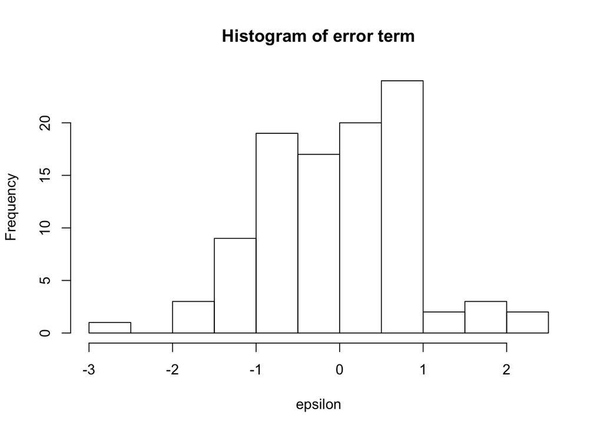

```r
my_gen_func <- function(N, rx1, rx2, beta, sigma, outfile="my_first_data_frame.csv"){
  X <- cbind(rep(1, N), seq(rx1[1], rx1[2], len=N), runif(N, min=rx2[1], max=rx2[2]))
  epsilon <- rnorm(N, 0, sigma)
  Y <- t(beta %*% t(X)) + epsilon
  df <- data.frame(Y=Y, x_1=X[,2], x_2=X[,3], epsilon=epsilon)
  write.csv(Y, file=outfile, row.names = F)
  hist(epsilon, main="Histogram of error term")
}
my_gen_func(100, c(0,10), c(2,12), beta=c(1,5,7), sigma=1)
```

#### Exercise 2 - Lists and `if`-`else` statements + communication skills

This exercise is about storing information (part 1) and communication (parts 1 and 2).

##### Part 1

In this part you will write a function able to create “cards” (lists) containing the following information:

- First name (character)
- Age in years (integer)
- Spoken languages (character vector of length $k_i$, with $i \in 1:N$)
- Favourite colours

We will solve the problem using lists, which provide a user-friendly and readable way of storing such information. Write and test a function that takes in input four arguments:

- name: a character name
- age: an integer
- lang: a character vector containing the spoken languages
- cols: a character vector containing the favourite colours

The function:

- prints a message on screen (using `cat()` or `print()`) along the lines of: “Robert, 23, can speak English, Mandarin and likes red, yellow.”
- collate all the information in a list and output it.

To solve this exercise, you need to use the `list()` command, along with the `paste()` and `cat()` or `print()` commands. In the script you are going to generate, write the function and a few commands to create different “cards”.

##### Part 2

When printing the message on screen, you could realise that creating a nicely formatted sentence is not trivial. When listing languages and colours, how to concatenate (`paste()`) the different words changes with the number of words to concatenate. In this part you will need to solve the following additional challenges *[Hint: you will need the command `length()`, and your life will get easier extending your knowledge of the `else` command to `else if`]*

- How can you print “English and Mandarin” instead of “English, Mandarin”? And “English, French and Mandarin” instead of “English, French, Mandarin”?
- Can you solve the previous problem in a general way, i.e., independantly of the number of languages?
- Can you manage the case with only one language or colour?
- Can you manage the case when there is no favourite language or colour? Two problems to solve:
  - Without a default input (e.g., lang=“English” in the function parameters), you must allocate a value when calling a function. How do you solve this from a user perspective? What do you want users to write in the function call? There are several possibilities, for example display a message asking them to input “None”. Another option is to allow users to just skip the `lang` and/or `colour` options. In that case, you need to have a default, e.g. `lang="0"` or `lang=NULL`. It is important for you to understand what `NULL` is, please research it.
  - What message are you going to show on screen when there is no favourite?
- Create a few “cards”. How can you save them? Please note that the command `write.csv()` is not fit for purpose, as lists are “structurally” different from data frames. Research this problem and find a possible solution based on the commands `save()` (and `load()` to retrieve the information). As an advice, it is better to first collect all cards in a single list (i.e. `cards <- list(bob, mary, bruce)`, a list of lists) and then save a single object.

```r
new_card <- function(name, age, langs=NULL, cols=NULL){
  card = list(name= name, age= age, langs= langs, cols= cols)
  # Deal with the number of languages
  if (length(langs)==0){
    langs_msg = "cannot speak any language (believe it or not!)"
  } else if (length(langs)==1){
    langs_msg = paste("can speak", langs)
  } else if (length(langs)==2){
    langs_msg = paste("can speak", langs[1], "and", langs[2])
  } else if (length(langs)>3){
    # We can collapse the first k-1 elements of a character k-vector using lang[-length(langs)]
    langs_str = paste(langs[-length(langs)], collapse=", ")
    # And then we add the last language separated by "and"
    langs_str = paste(langs_str, "and", langs[length(langs)])
    langs_msg = paste("can speak", langs_str)
  }
  # Deal with the number of colours
  if (length(cols)==0){
    cols_msg = "does not like any colour (so sad)"
  } else if (length(cols)==1){
    cols_msg = paste("likes", cols)
  } else if (length(cols)==2){
    cols_msg = paste("likes", cols[1], "and", cols[2])
  } else if (length(cols)>=3){
    # We can collapse the first k-1 elements of a character k-vector using lang[-length(cols)]
    cols_str = paste(cols[-length(cols)], collapse=", ")
    # And then we add the last language separated by "and"
    cols_str = paste(cols_str, "and", cols[length(cols)])
    cols_msg = paste("likes", cols_str)
  }
  # Show message
  cat(name, ", ", age, ", ", langs_msg, " and ", cols_msg, ".\n", sep="")
  # Output
  card
}

# Create some cards
bob_card = new_card(name="Bob", age=23, langs=c("English", "Mandarin"), cols=c("red", "blue"))
```

```
## Bob, 23, can speak English and Mandarin and likes red and blue.
```

```r
mary_card = new_card(name="Mary", age=27, langs=c("English"), cols=c("red", "blue", "yellow"))
```

```
## Mary, 27, can speak English and likes red, blue and yellow.
```

```r
bruce_card = new_card(name="Bruce", age=18)
```

```
## Bruce, 18, cannot speak any language (believe it or not!) and does not like any colour (so sad).
```

```r
# Collect cards in a single object
cards = list(bob=bob_card, mary=mary_card, bruce=bruce_card)
cards
```

```
## $bob
## $bob$name
## [1] "Bob"
##
## $bob$age
## [1] 23
##
## $bob$langs
## [1] "English"  "Mandarin"
##
## $bob$cols
## [1] "red"  "blue"
##
##
## $mary
## $mary$name
## [1] "Mary"
##
## $mary$age
## [1] 27
##
## $mary$langs
## [1] "English"
##
## $mary$cols
## [1] "red"    "blue"   "yellow"
##
##
## $bruce
## $bruce$name
## [1] "Bruce"
##
## $bruce$age
## [1] 18
##
## $bruce$langs
## NULL
##
## $bruce$cols
## NULL
```

```r
## Saving
save(cards, file="cards.RData")
## Delete the object "cards"
rm(cards)
## Check that the object does not exist any more, by checking the "Environment" tab in RStudio, or simply by typing "cards"
#Loading
load(file="cards.RData")
# The object cards should be back. Check as before.
cards
```

```
## $bob
## $bob$name
## [1] "Bob"
##
## $bob$age
## [1] 23
##
## $bob$langs
## [1] "English"  "Mandarin"
##
## $bob$cols
## [1] "red"  "blue"
##
##
## $mary
## $mary$name
## [1] "Mary"
##
## $mary$age
## [1] 27
##
## $mary$langs
## [1] "English"
##
## $mary$cols
## [1] "red"    "blue"   "yellow"
##
##
## $bruce
## $bruce$name
## [1] "Bruce"
##
## $bruce$age
## [1] 18
##
## $bruce$langs
## NULL
##
## $bruce$cols
## NULL
```